# 102 Flower Project

- Introduction
- Data Collection and Preparation
- Libraries Needed
- Exploratory Data Analysis
- Data Model Approach
- More Suggestion
- Q/A

# Introduction

102 Flower is an image classification dataset consisting of 102 flower categories. The flowers chosen to be flower commonly occurring in the United Kingdom. Each class consists of between 40 and 258 images.

The images have large scale, pose and light variations. In addition, there are categories that have large variations within the category and several very similar categories

# Data Collection and Preparation

Dataset contains 8189 images is splited into 80:10:10 Train:Valid:Test split where Train & Valid are labeled using folders with class_id into one directory.

but Test are unlabeled to know performance of model on unseen data

# Libraries Needed

```python
import numpy as np
import matplotlib.pyplot as plt
import json
import tensorflow as tf
```

```python
from google.colab import drive
drive.mount('/content/drive')
```

```python
# !unzip  '/content/drive/MyDrive/fellowship dataset/dataset.zip' -d '/content/drive/MyDrive/fellowship dataset/'
```

```python
img_height = 224
img_width = 224

# Train_ds and Valid_ds
train_ds = tf.keras.utils.image_dataset_from_directory(
  '/content/drive/MyDrive/fellowship dataset/dataset/train',
  validation_split=None,
  image_size=(img_height, img_width),
  batch_size=128,
  seed=42,
  shuffle=True)

val_ds = tf.keras.utils.image_dataset_from_directory('/content/drive/MyDrive/fellowship dataset/dataset/valid',
  validation_split=None,
  image_size=(img_height, img_width),
  batch_size=128,
  seed=42,
  shuffle=True)
```

```
Found 6552 files belonging to 102 classes.
Found 818 files belonging to 102 classes.
```

```python
# since train_ds have folder names so let's check them
class_names = train_ds.class_names
class_names
```

```
['1',
 '10',
 '100',
 '101',
 '102',
 '11',
 '12',
 '13',
 '14',
 '15',
 '16',
 '17',
 '18',
 '19',
 '2',
 '20',
 '21',
 '22',
 '23',
 '24',
 '25',
 '26',
 '27',
 '28',
 '29',
 '3',
 '30',
 '31',
 '32',
 '33',
 '34',
 '35',
 '36',
 '37',
 '38',
 '39',
 '4',
 '40',
 '41',
 '42',
```

[output cut: 47 more lines]

```
 '86',
 '87',
 '88',
 '89',
 '9',
 '90',
 '91',
 '92',
 '93',
 '94',
 '95',
 '96',
 '97',
 '98',
 '99']
```

```python
# mapping folder name to class name (for evaluating result at last step)

def get_flower_name(val):
    return cat_to_name[train_ds.class_names[val]]

file = open('/content/drive/MyDrive/fellowship dataset/cat_to_name.json')
cat_to_name = json.load(file)
cat_to_name
```

```
{'21': 'fire lily',
 '3': 'canterbury bells',
 '45': 'bolero deep blue',
 '1': 'pink primrose',
 '34': 'mexican aster',
 '27': 'prince of wales feathers',
 '7': 'moon orchid',
 '16': 'globe-flower',
 '25': 'grape hyacinth',
 '26': 'corn poppy',
 '79': 'toad lily',
 '39': 'siam tulip',
 '24': 'red ginger',
 '67': 'spring crocus',
 '35': 'alpine sea holly',
 '32': 'garden phlox',
 '10': 'globe thistle',
 '6': 'tiger lily',
 '93': 'ball moss',
 '33': 'love in the mist',
 '9': 'monkshood',
 '102': 'blackberry lily',
 '14': 'spear thistle',
 '19': 'balloon flower',
 '100': 'blanket flower',
 '13': 'king protea',
 '49': 'oxeye daisy',
 '15': 'yellow iris',
 '61': 'cautleya spicata',
 '31': 'carnation',
 '64': 'silverbush',
 '68': 'bearded iris',
 '63': 'black-eyed susan',
 '69': 'windflower',
 '62': 'japanese anemone',
 '20': 'giant white arum lily',
 '38': 'great masterwort',
 '4': 'sweet pea',
 '86': 'tree mallow',
 '101': 'trumpet creeper',
```

[output cut: 47 more lines]

```
 '75': 'thorn apple',
 '41': 'barbeton daisy',
 '95': 'bougainvillea',
 '43': 'sword lily',
 '83': 'hibiscus',
 '78': 'lotus lotus',
 '88': 'cyclamen',
 '94': 'foxglove',
 '81': 'frangipani',
 '74': 'rose',
 '89': 'watercress',
 '73': 'water lily',
 '46': 'wallflower',
 '77': 'passion flower',
 '51': 'petunia'}
```

```python
# if given tag_name so convert it to numeric for training the RestNet

def to_internal_tag(name_tag):
    return train_ds.class_names.index(str(name_tag))
```

# 1) Exploratory Data Analysis

### a) Let's Visualize some images

### b) check frequncy of classes

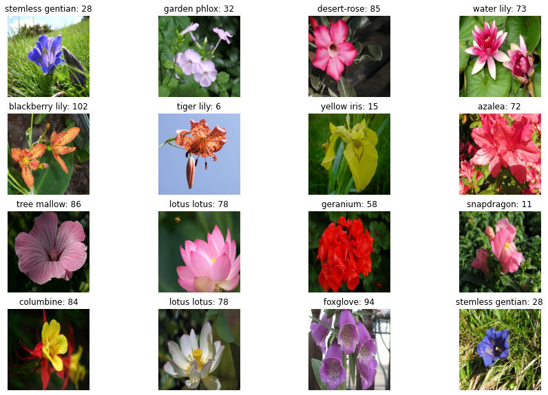

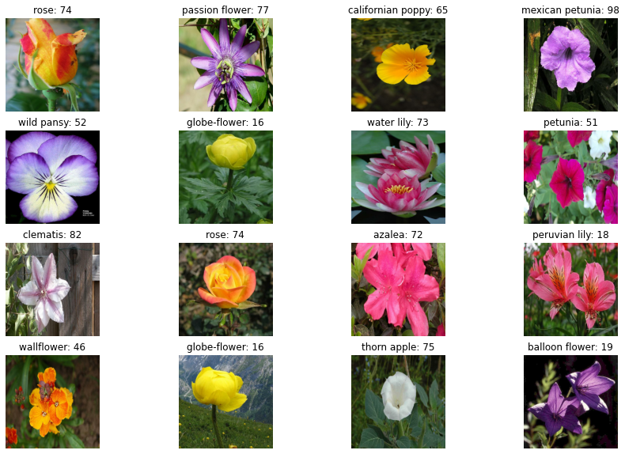

```python
# a) Let's Visualize some images
for data in train_ds.take(2):
    images, labels = data[0], data[1]

    _, ax = plt.subplots(4, 4, figsize=(15, 10))

    for i in range(16): # half number of batch
        img = np.array(images[i]).astype('uint8')
        label = labels[i]
        label = get_flower_name(label) + ": "+str(np.array(class_names[label]))

        ax[i // 4, i % 4].imshow(img)
        ax[i // 4, i % 4].set_title(label)
        ax[i // 4, i % 4].axis("off")

plt.show()
```

```python
# b) check frequncy of classes
all_labels = []
for data in train_ds.take(-1):
    labels = data[1]
    all_labels.append(np.array(labels))

def freq_get(all_labels):
    dicto = {}
    for num in range(0, 102):
        dicto[str(num)] = 0
        for i in range(len(all_labels)):
            for j in range(len(all_labels[i])):
                if num == all_labels[i][j]:
                    dicto[str(num)] += 1
    return dicto
dicto = freq_get(all_labels)
dicto
```

```
{'0': 27,
 '1': 38,
 '2': 35,
 '3': 49,
 '4': 36,
 '5': 68,
 '6': 73,
 '7': 38,
 '8': 44,
 '9': 38,
 '10': 36,
 '11': 60,
 '12': 65,
 '13': 38,
 '14': 49,
 '15': 46,
 '16': 34,
 '17': 47,
 '18': 72,
 '19': 35,
 '20': 34,
 '21': 33,
 '22': 36,
 '23': 55,
 '24': 62,
 '25': 36,
 '26': 61,
 '27': 48,
 '28': 36,
 '29': 31,
 '30': 28,
 '31': 33,
 '32': 62,
 '33': 92,
 '34': 44,
 '35': 33,
 '36': 44,
 '37': 54,
 '38': 97,
 '39': 49,
```

[output cut: 47 more lines]

```
 '87': 48,
 '88': 51,
 '89': 116,
 '90': 153,
 '91': 41,
 '92': 66,
 '93': 59,
 '94': 53,
 '95': 34,
 '96': 132,
 '97': 101,
 '98': 72,
 '99': 54,
 '100': 68,
 '101': 50}
```

```python
values = list(dicto.values())
np.min(values), np.max(values) # classes are imbalanced colud be solved by augmentation
```

```
(27, 206)
```

```python
# data augmentation


# (normalization + same preprocessing as pretrained model paper)
## done inside arch normalization + same preprocessing
```